# Basketball’s Offensive Evolution

Ryan Thomas & Michael Dara

7/6/2021

## Introduction

In the last couple of years, basketball viewers know that the game has turned out to be all about offense and scoring. This means that players are aiming to score way more, the tempo is faster, and the 3-point shot is the best type of shot now. From an overarching view, it can be seen that basketball has shifted into a “European style” of play. European style basketball is considered team oriented fundamental basketball, which focuses on high basketball IQ, fundamentals, team spacing and tough defense. This style is more and more fitting as years have gone by, because players’ individual skill sets have improved drastically. In turn, players are expected to have all essential skills on the court, such as shooting, rebounding, and passing, rather than choosing players based on one specific strength they have.

## Background Info

This trend is most prevalent in the NBA, and in recent years, the three-point barrage has reached an all time high. According to the Wall Street Journal, “Twenty years ago, 17% of NBA shots were threes. Ten years ago, it was 22%. Five years ago, it climbed to 28%. And it didn’t stop there. The 3-point rate across the entire league kept rising until it soared near another milestone in the first month of this season: It’s settling at almost exactly 40%”. Furthermore, now there are 15 teams (half of the league) that are shooting the ball at this rate! (https://www.wsj.com/articles/nba-3-point-revolution-11611190418)

Seeing NBA players like Stephen Curry, who shoots three-pointers 10 feet behind the line, has influenced the younger generations to do the same.

## Project Description and Analysis

So, to dive deeper into this phenomenon, our group has decided to investigate whether or not this offensive trend trickles down into the NCAA level. In doing so, we can determine whether other basketball leagues have also adopted this European style of play. This analysis is important for all of basketball, because women basketball players and their respective leagues can benefit the most, in terms of viewership and increasing revenue. Finally, it influences the younger generations into following the same style with their own teams.

When starting our project, we needed to acquire a dataset that best represented the last couple of seasons in NCAA Men’s Basketball. With the help of Andrew Sundberg, a Kaggle user, we were able to import a dataset of all the teams’ statistics in Men’s Division 1 Basketball from 2013-2019. For those who are not familiar with Kaggle, it is essentially a website that has many datasets covering any kind of topic or subject you can think of. After researching our acquired dataset, we decided to tidy it up because there were too many teams and conferences to deal with. From a dataset of about 2,500 rows, we were able to narrow it down to a little over 500 rows. We did it by extracting the top 6 conferences in the NCAA, since these conferences contain more influential players like NBA prospects and coaches that have been well-known for years. In doing so, we focused our sample on teams that are heavily watched and more comparable amongst each other, reducing the variability in our statistical modeling. The 6 conferences we selected are as follows: Atlantic Coast Conference (ACC), Big Ten (B10), Big Twelve (B12), Big East (BE), Pac-12 (P12), and Southeastern Conference (SEC).

After extracting the necessary data from our set, we were able to properly view the variables associated with it. The main numerical variables that we analyzed were: adjusted tempo, 3-point shooting rate, free-throw rate, turnover-rate, effective field-goal rate, and wins-above-bubble rate (WAB). For those who are not aware, WAB is the number of games won above the bubble, the bubble being the cutoff for teams who do and don’t make the NCAA national tournament. Using these numerical variables, we were able to compare our categorical variables, which were conference, postseason seed, and year.

Once we determined all the possible variables to use, it was time to start formulating models to prove our point that the NCAA too has moved towards a European style of play. Our first major hypothesis was that a higher effective 3-point shooting rate would lead to a higher WAB, and in creating that, we made a scatterplot between those two variables. In order to better understand our plot, we separated the points on that plot by using color to determine postseason achievement. In this context, postseason achievement is the place a team finished in the NCAA national tournament, with NA being teams that didn’t make the tournament.

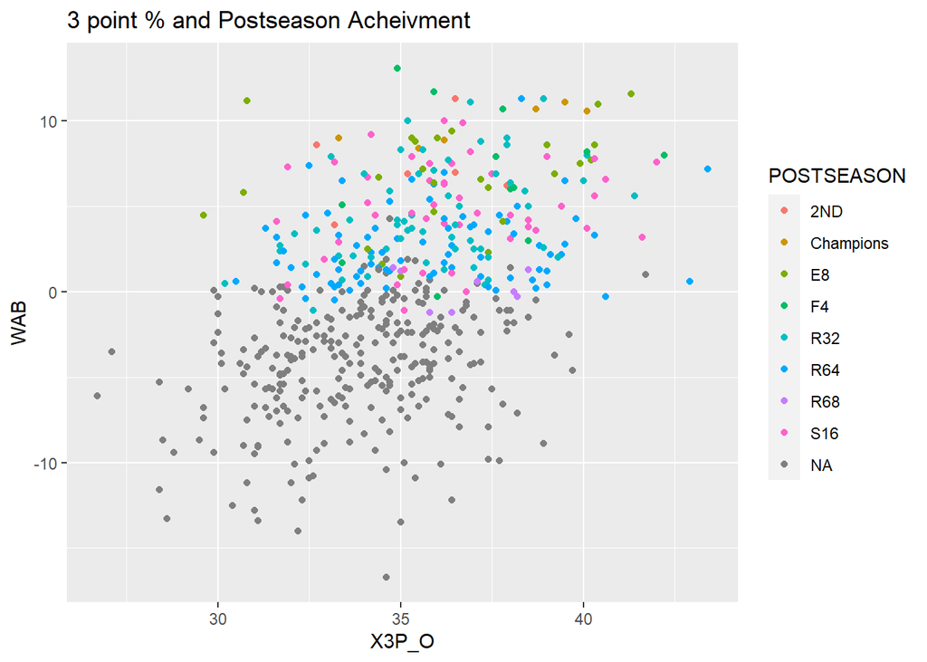

On the other hand, however, critics may complain that this increased tempo leads to more turnovers than scoring opportunities. Their additional arguments for this style of play is that it is a bad adaptation for amateur level basketball players. NBA players are not comparable to NCAA players, as there is a large talent disparity between the two, however, our research on the NCAA in recent years shows that these players are still able to control the flow of the game with an increase in tempo. To refute their argument, we devised a plot showing the relationship between tempo and turnover rate.

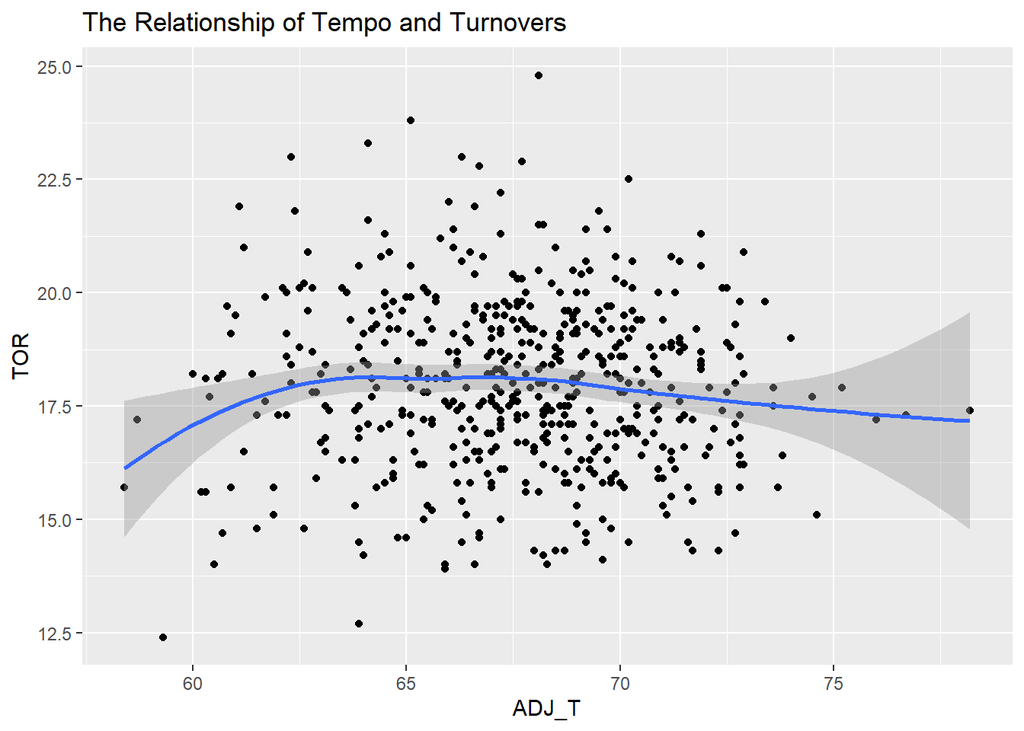

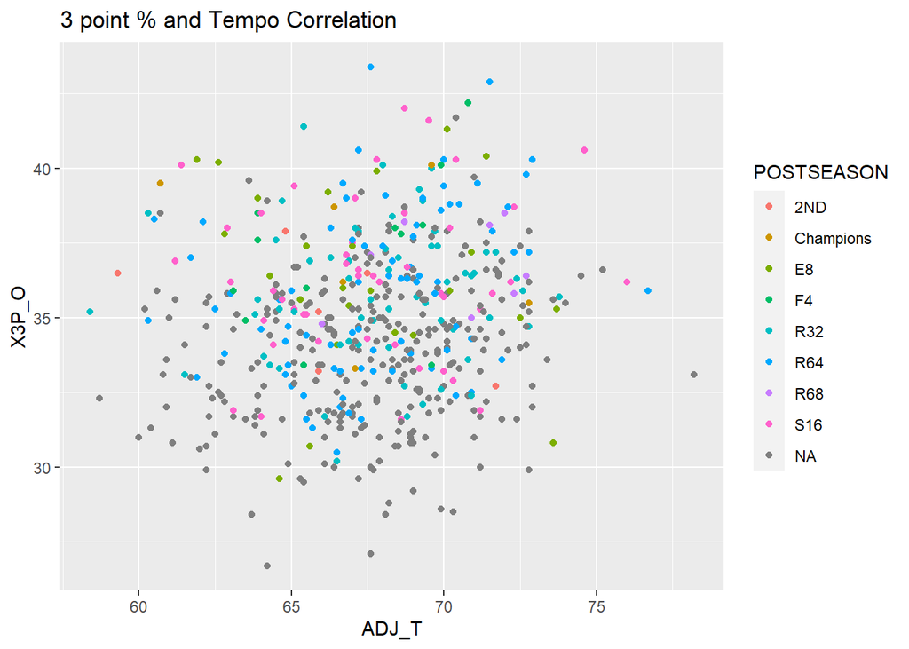

As you can see above, comparing 3 point rates and tempo rates amongst postseason achievement displayed a very weak positive correlation between the two variables, and it was indicative that postseason achievement didn’t have much to do with tempo. However, from our previous research, it is pretty clear that a team’s 3-point rate is vital in adopting the European style of play.